# FigureYa78gganatogram

小丫画图出品

2019-2-24

欢迎关注“小丫画图”公众号，同名知识星球等你加入

小丫微信: epigenomics E-mail: figureya@126.com

作者：小丫

## 需求描述

用FigureYa55panCancer输出的基因在TCGA + GTEx的表达量TPM值（easy_input.csv文件）作为输入，用gganatogram画出感兴趣的基因在各个器官里的表达分布。

## 应用场景

gganatogramR包介绍：https://github.com/jespermaag/gganatogram，https://mp.weixin.qq.com/s/BlRT8I0RB1o-Mi4TEWhFrQ

文章里类似的图举例：https://mp.weixin.qq.com/s/Uc6syOjFTOduxZfVaZRPqw

在小丫画图公众号回复“器官”，查看更多介绍。

## 环境设置

```r
#devtools::install_github("jespermaag/gganatogram")
library(gganatogram)
library(stringr)
library(gridExtra)

Sys.setenv(LANGUAGE = "en") #显示英文报错信息
options(stringsAsFactors = FALSE) #禁止chr转成factor
```

## 输入文件预处理

如果你的数据已经整理成very_easy_input.csv的格式，就可以跳过这步，进入“开始画图”。

此处以FigureYa55panCancer输出的的基因在TCGA + GTEx的表达量TPM值（easy_input.csv文件）为例，需要把TCGA的癌症名称跟包里的organ对应上。

参照GEPIA help的Differential analysis：http://gepia.cancer-pku.cn/help.html，在此基础上添加gganatogram包的organ，整理成TCGA_organ.txt文件，欢迎来小丫画图群里探讨这些对应关系。

```r
# TCGA和GTEx的tumor和normal的TPM
df <- read.csv("easy_input.csv", row.names = 1)
head(df)
```

```
##   tissue type2    tpm
## 1    ACC tumor 4.1327
## 2    ACC tumor 4.9519
## 3    ACC tumor 3.0619
## 4    ACC tumor 2.7051
## 5    ACC tumor 1.9749
## 6    ACC tumor 3.1079
```

```r
df$tt <- paste(df$tissue, df$type2, sep = "_")
df.median <- aggregate(.~tt, df[,3:4], median)
df.median$TCGA <- str_split_fixed(df.median$tt, "_",2)[,1]
df.median$type <- str_split_fixed(df.median$tt, "_",2)[,2]
df.median$tt <- NULL

### 把TCGA癌症名称缩写换成gganatogram包里的organ
#根据背景知识，已整理成TCGA_organ
#Name列来源：https://cn.bing.com/translator
TCGA.organ <- read.table("TCGA_organ.txt", sep = "\t", header = T)
TCGA.organ[,c(1:2,4)]
```

```
##    TCGA                                Detail           organ
## 1  BRCA             breast invasive carcinoma          breast
## 2  PRAD               prostate adenocarcinoma        prostate
## 3    OV     ovarian serous cystadenocarcinoma           ovary
## 4  PCPG      pheochromocytoma & paraganglioma
## 5   GBM               glioblastoma multiforme           brain
## 6  HNSC   head & neck squamous cell carcinoma
## 7  UCEC uterine corpus endometrioid carcinoma          uterus
## 8   UCS                uterine carcinosarcoma          uterus
## 9  CESC        cervical & endocervical cancer  uterine_cervix
## 10 DLBC         diffuse large B-cell lymphoma
## 11 LAML                acute myeloid leukemia     bone_marrow
## 12 THCA                     thyroid carcinoma   thyroid_gland
## 13 SKCM               skin cutaneous melanoma            skin
## 14 READ                 rectum adenocarcinoma           colon
```

[output cut: 19 more lines]

```r
TCGA.organ.tpm <- merge(TCGA.organ[,c(1,4)], df.median, by = "TCGA")
TCGA.organ.tpm$TCGA <- NULL
TCGA.organ.tpm <- TCGA.organ.tpm[TCGA.organ.tpm$organ != "",]
# 男人
hgMale_key_tpm <- merge(hgMale_key, TCGA.organ.tpm, by = "organ")
hgMale_key_tpm$value <- hgMale_key_tpm$tpm #替换掉原来的value
hgMale_key_tpm$tpm <- NULL
write.csv(hgMale_key_tpm,"very_easy_input_Male.csv", quote = F, row.names = F)
# 女人
hgFemale_key_tpm <- merge(hgFemale_key, TCGA.organ.tpm, by = "organ")
hgFemale_key_tpm$value <- hgFemale_key_tpm$tpm
hgFemale_key_tpm$tpm <- NULL
write.csv(hgFemale_key_tpm,"very_easy_input_Female.csv", quote = F, row.names = F)
```

**附：** 查看gganatogram包里的organ：

```r
#男人
hgMale_key$organ
```

```
##  [1] "thyroid_gland"             "bone_marrow"
##  [3] "frontal_cortex"            "prefrontal_cortex"
##  [5] "pituitary_gland"           "aorta"
##  [7] "gastroesophageal_junction" "left_ventricle"
##  [9] "caecum"                    "ileum"
## [11] "rectum"                    "nose"
## [13] "breast"                    "tongue"
## [15] "left_atrium"               "pulmonary_valve"
## [17] "mitral_valve"              "penis"
## [19] "nasal_pharynx"             "spinal_cord"
## [21] "throat"                    "tricuspid_valve"
## [23] "diaphragm"                 "liver"
## [25] "stomach"                   "spleen"
## [27] "duodenum"                  "gall_bladder"
## [29] "pancreas"                  "colon"
```

[output cut: 19 more lines]

```r
#女人
#hgFemale_key$organ
#男女差异
setdiff(hgMale_key$organ, hgFemale_key$organ)
```

```
## [1] "tongue"          "penis"           "vas_deferens"    "seminal_vesicle"
## [5] "epididymis"      "amygdala"        "testis"          "prostate"
```

```r
#雄鼠
#mmMale_key$organ
#雌鼠
#mmFemale_key$organ

#细胞
#cell_key[['cell']]$organ

#支持的其他物种
names(other_key)
```

```
##  [1] "anolis_carolinensis"
##  [2] "arabidopsis_thaliana"
##  [3] "bos_taurus"
##  [4] "brachypodium_distachyon.flower_parts"
##  [5] "brachypodium_distachyon.whole_plant"
##  [6] "gallus_gallus"
##  [7] "hordeum_vulgare.flower_parts"
##  [8] "hordeum_vulgare.whole_plant"
##  [9] "macaca_mulatta"
## [10] "monodelphis_domestica"
## [11] "oryza_sativa.flower_parts"
## [12] "oryza_sativa.whole_plant"
## [13] "papio_anubis"
## [14] "rattus_norvegicus"
## [15] "solanum_lycopersicum.flower_parts"
## [16] "solanum_lycopersicum.whole_plant"
## [17] "sorghum_bicolor.flower_parts"
## [18] "sorghum_bicolor.whole_plant"
## [19] "tetraodon_nigroviridis"
## [20] "triticum_aestivum.flower_parts"
## [21] "triticum_aestivum.whole_plant"
## [22] "xenopus_tropicalis"
## [23] "zea_mays.flower_parts"
## [24] "zea_mays.whole_plant"
```

```r
#以拟南芥为例查看organ
#other_key[["arabidopsis_thaliana"]]$organ
```

## 开始画图

very_easy_input.csv，organ对应的数值。

- 第一列是组织器官名，必须跟包里的organ一致
- 第二列color，每种organ给一种颜色
- 第三列组织所在的系统
- 第四列数值，可以是基因表达量，或者其他临床指标。
- 第五列tumor和normal

其中第一列和第四列为必需

此处以人类为例，分别画男人和女人，对比tumor和normal。

还可以男女都画，然后ps成一半男一半女。

其他物种按照very_easy_input_*.csv的格式整理好数据，就可以套用了

```r
#画女人
hgFemale_tpm <- read.csv("very_easy_input_Female.csv")
head(hgFemale_tpm)
```

```
##           organ  colour         type.x   value type.y
## 1 adrenal_gland #41ab5d          other 3.85310  tumor
## 2 adrenal_gland #41ab5d          other 3.60360 normal
## 3   bone_marrow #41ab5d          other 5.80170  tumor
## 4   bone_marrow #41ab5d          other 1.72290 normal
## 5         brain  purple nervous_system 4.90840  tumor
## 6         brain  purple nervous_system 5.41465  tumor
```

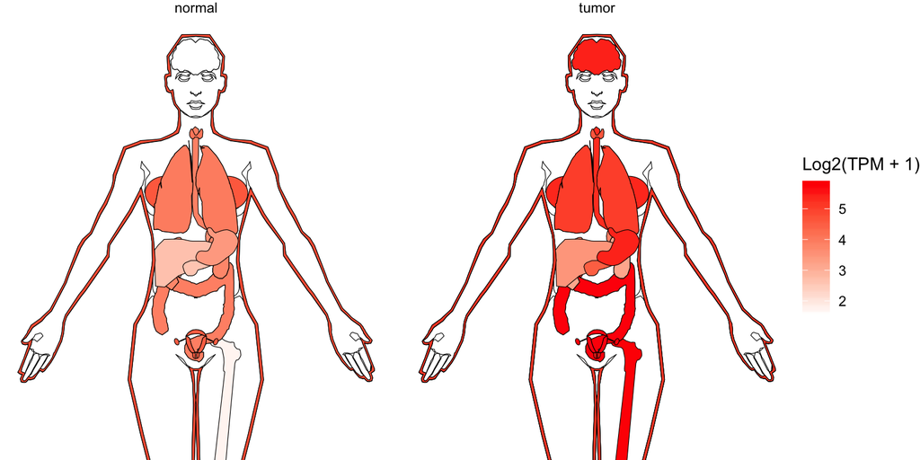

```r
hgFemale_tpm$type <- hgFemale_tpm$type.y #或对比不同的系统，换成type.x

#注意：
#fill里要么是color，要么是value，你自己数据的列名要跟它一致
#facet_wrap里的type，必须是type，你自己数据的列名要跟它一致
hgFemale <- gganatogram(data=hgFemale_tpm,
                        fillOutline='white', #没有organ的位置用白色填充
                        #human、mouse或cell，其他物种拉丁名用names(other_key)查看
                        organism='human',
                        sex='female', #性别
                        fill="value") + #还可以用color列填充
  facet_wrap(~type) + #对比tumor和normal
  #用value填充时，可以设置渐变色
  scale_fill_gradient(low = "white", high = "red") +
  labs(fill = "Log2(TPM + 1)") +
  coord_cartesian(ylim = c(-120, 0))+ #不画小腿，如果想画到脚，就去掉这行
  theme_void() #不画坐标轴

hgFemale
```

```r
#画男人
hgMale_tpm <- read.csv("very_easy_input_Male.csv")
head(hgMale_tpm)
```

```
##           organ         type.x  colour  value type.y
## 1 adrenal_gland          other #41ab5d 3.8531  tumor
## 2 adrenal_gland          other #41ab5d 3.6036 normal
## 3   bone_marrow          other #41ab5d 5.8017  tumor
## 4   bone_marrow          other #41ab5d 1.7229 normal
## 5         brain nervous_system  purple 4.9084  tumor
## 6         brain nervous_system  purple 1.5366 normal
```

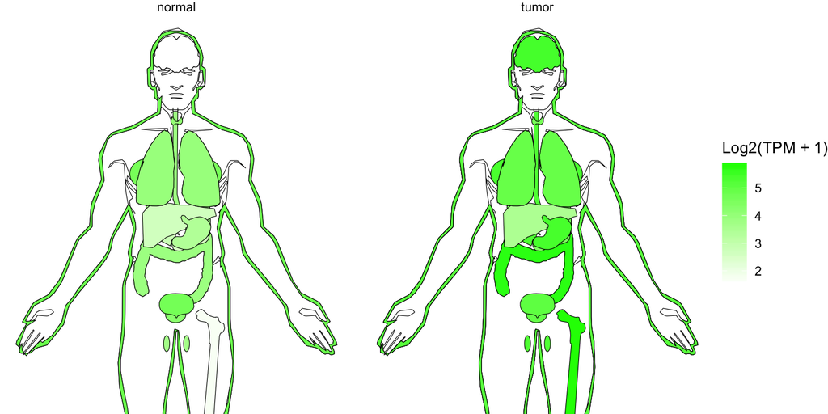

```r
hgMale_tpm$type <- hgMale_tpm$type.y
hgMale <- gganatogram(data=hgMale_tpm, fillOutline='white', organism='human', sex='male', fill="value") +
  facet_wrap(~type) +
  scale_fill_gradient(low = "white", high = "green") +
  labs(fill = "Log2(TPM + 1)") +
  coord_cartesian(ylim = c(-120, 0)) +
  theme_void()

hgMale
```

```r
#组图并保存到pdf文件
pdf("gganatogram.pdf")
grid.arrange(hgFemale, hgMale, ncol=1)
dev.off()
```

[figure not shown]

上图有些组织被盖住了，分开画更清晰。

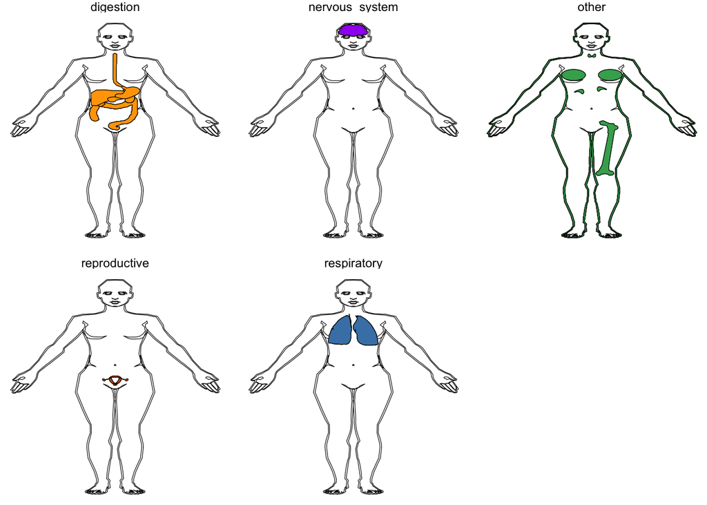

```r
hgFemale_tpm$type <- hgFemale_tpm$type.x #换成type.x
gganatogram(data=hgFemale_tpm,
            fillOutline='white',
            organism='human',
            sex='female',
            fill="color") + #用color列的颜色填充
  facet_wrap(~type) +
  theme_void()
```